# Between subject MANOVA Tutorial

Mo’men Mohamed

April 5, 2019

This a tutorial for doing between subject MANOVA

you are welcome to contact me for any advice or recommendation at: vet.m.mohamed@gmail.com

for Complete tutorial and data set see [here](http://statstools.com/learn/advanced-statistics/)

first of all lets load libraries which we are going to use in this Analysis and clearing the work space

```r
library(tidyverse)
library(car)
library(multcomp)
library(ez)
library(MOTE)
library(psych)
```

Then lets import the data set

```r
data<-read.csv("./data sets/9 manova.csv")
head(data)
```

```
##   CASENO  FEM MASC ESTEEM CONTROL ATTROLE SEL2 INTEXT NEUROTIC
## 1   1250 High  Low     19      10      33   44      2       18
## 2   2060 High  Low     17       6      32    3      5       NA
## 3   2170 High  Low     26       6      35   11      3        7
## 4    380  Low  Low     27       9      34   13      3       17
## 5    780  Low  Low     22       6      34   27      3        8
## 6   3350 High High     12       8      49   62      3        1
```

lets take the analysis variables out

```r
data<-data[,c("FEM","MASC","ESTEEM","ATTROLE","NEUROTIC")]
```

adding individual index

```r
data<-data%>%mutate(idx=1:n())
```

Now lets test the assumptions and the appropriateness of the data to MANOVA

We will start by accuracy and missing data

```r
summary(data)
```

```
##    FEM        MASC         ESTEEM         ATTROLE         NEUROTIC
##  High:262   High:125   Min.   : 8.00   Min.   :18.00   Min.   : 0.000
##  Low :107   Low :244   1st Qu.:13.00   1st Qu.:30.00   1st Qu.: 5.000
##                        Median :16.00   Median :35.00   Median : 9.000
##                        Mean   :15.75   Mean   :35.01   Mean   : 8.752
##                        3rd Qu.:18.00   3rd Qu.:40.00   3rd Qu.:12.000
##                        Max.   :29.00   Max.   :62.00   Max.   :23.000
##                                                        NA's   :62
##       idx
##  Min.   :  1
##  1st Qu.: 93
##  Median :185
##  Mean   :185
##  3rd Qu.:277
##  Max.   :369
##
```

In Neurotic we have a large numbers of Na’s

So we have to see the percentage of the missing data

```r
apply(data,2,function(x){
        sum(is.na(x))/length(x)
})
```

```
##       FEM      MASC    ESTEEM   ATTROLE  NEUROTIC       idx
## 0.0000000 0.0000000 0.0000000 0.0000000 0.1680217 0.0000000
```

Now lets test for outliers using maharanis test

```r
mah<-mahalanobis(x = data[,-c(1,2,6)],
                 center = colMeans(data[,-c(1,2,6)],na.rm = T),cov = cov(data[,-c(1,2,6)],use = "pairwise.complete.obs"))
```

determining the cutoff point through chi square distribution

```r
cut<-qchisq(p = .99,df = 2)
```

summary of the outliers

```r
summary(mah<cut)
```

```
##    Mode   FALSE    TRUE    NA's
## logical       9     298      62
```

we have 9 outliers and we have to remove them

```r
data<-data[which(mah<cut),]
```

Now lets move to the second phase :

testing the normality - linearity - Homogeneity - Homoscdasticity

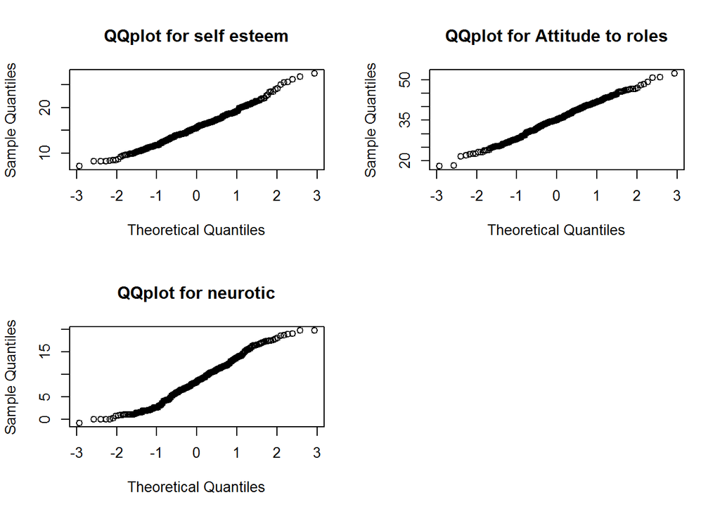

```r
par(mfrow=c(2,2))
qqnorm(data$ESTEEM%>%jitter(factor = 5),main = "QQplot for self esteem")
qqnorm(data$ATTROLE%>%jitter(factor = 5),main = "QQplot for Attitude to roles")
qqnorm(data$NEUROTIC%>%jitter(factor = 5),main = "QQplot for neurotic")
```

Other way : making fake data for fake regression to test the assumption in multivariate way

```r
set.seed(345)
rfake<-rchisq(n = nrow(data),7)
```

the df is arbitrary number

```r
fakelm<-data%>%with(lm(rfake~ESTEEM+ATTROLE+NEUROTIC))
```

Now lets Extract the residual and fitted values

```r
stdresid<-resid(fakelm)%>%scale()
stdfit<-fitted(fakelm)%>%scale()
```

start with normality we can check it using qqnorm plot

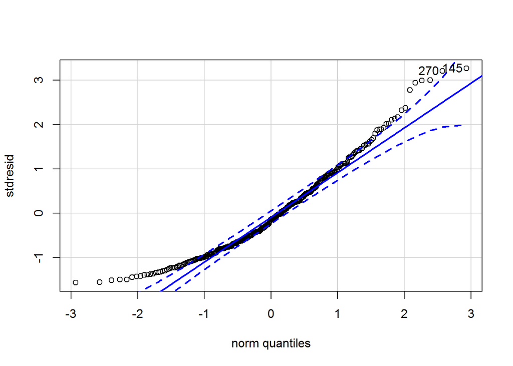

```
## [1] 145 270
```

```r
qqPlot(stdresid)
```